# MigConnectivity package: worked example

Jeffrey A. Hostetler, Michael T. Hallworth, Henry Stevens

2025-03-31

This vignette is intended to help users structure their data for analysis using the MigConnectivity package. There are many ways to derive the data needed for analysis and below, we provided examples and code as a reference for users. However, the most appropriate methods and approaches for particular questions and data types should be considered by the users.

There are examples at the end of this vignette that illustrate ways to calculate bias and variance metrics using light-level geolocator data derived from the SGAT and FLightR packages.

## Using data integration to estimate the strength of migratory connectivity

This MigConnectivity package provides tools for estimating the pattern and strength of migratory connectivity. We’ve developed methods to integrate intrinsic markers, tracking, and band reencounter data collected from the same or different individuals. The package functionality includes integrated analyses that account for differences in precision, bias, reencounter probability, and directionality among different data types (banding reencounter, light-level geolocator, stable isotopes in tissues, genetics, and GPS). The package separates estimation of migratory connectivity into two functions: estTransition and estStrength. The `estTransition` function estimates transition probabilities (ψ) from seasonal movement data (i.e. pattern of movement) and the `estStrength` estimates the strength of migratory connectivity (MC) from transition probabilities.

Below we provide a worked example using Yellow Warbler (*Setophaga petechia*) data (Hostetler et al. 2025) to help users format their data to use the new functionality in the MigConnectivity package. There are multiple published Yellow Warbler data sets that can be used to estimate migratory connectivity. Here, we illustrate how to integrate genetic data and light-level geolocators to estimate MC. Genetic sampling of 203 individuals occurred at 20 locations across the nonbreeding range, from Baja Mexico, south through central Mexico, Central America (Costa Rica and Nicaragua), and South America (Trinidad and Venezuela) (Bay et al. 2021).

### Define nonbreeding regions

We identified 4 nonbreeding regions using ecoregions which include the Pacific and Central Mexico, Atlantic Lowland Mexico, Central America and South America.

```r
library(MigConnectivity)
library(sf)
library(terra)

set.seed(1)

newDir <- tempdir()
baseURL <- 'https://github.com/SMBC-NZP/MigConnectivity/blob/devpsi2/data-raw/YEWA/'
file.name <- "YEWA_target_sites.rds"
url1 <- paste0(baseURL, file.name, '?raw=true')
temp <- paste(newDir, file.name, sep = '/')
utils::download.file(url1, temp, mode = 'wb')
YEWA_target_sites <- readRDS(temp)
unlink(temp)

YEWA_target_sites <- YEWA_target_sites[,c("Region","targetSite","geometry")]

# vector of target names #
targetNames <- c("Pacific and Central Mexico", "Atlantic Lowland Mexico",
                 "Central America", "South America")
```

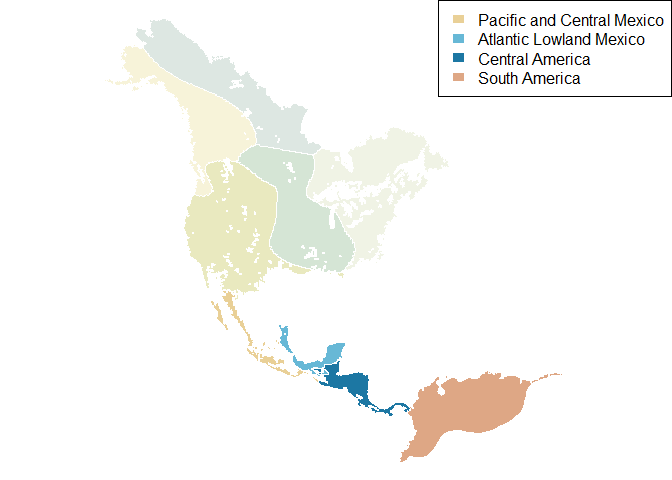

Yellow Warbler nonbreeding regions. The breeding regions (washed out) are defined by genoscape-defined populations and the nonbreeding regions were identified by ecoregions across the ranges

### Define breeding regions

The Yellow Warbler genoscape identifies 5 genetically distinct breeding populations (Arctic, Pacific Northwest, Southwest, Central, and East) from 419 sampled individuals at 50 breeding locations (Bay et al. 2021).

Below we create a vector of the origin names. These names correspond with the genoscape.

```r
# Load shapefile of origin sites derived from genoscape data
# Define the origin sites
file.names <- paste0("originSitesYEWA.", c("shp", "dbf", "prj", "shx"))
urls <- paste0(baseURL, file.names, '?raw=true')
temp <- paste(newDir, file.names, sep = '/')
for (i in 1:length(file.names))
  utils::download.file(urls[i], temp[i], mode = 'wb')
YEWA_origin_sites <- sf::st_read(temp[1], quiet = TRUE)
# vector of origin names
originNames <- c("Arctic", "Pacific Northwest", "Southwest", "Central", "East")

# object with the number of originSites
nOriginSites <- 5
```

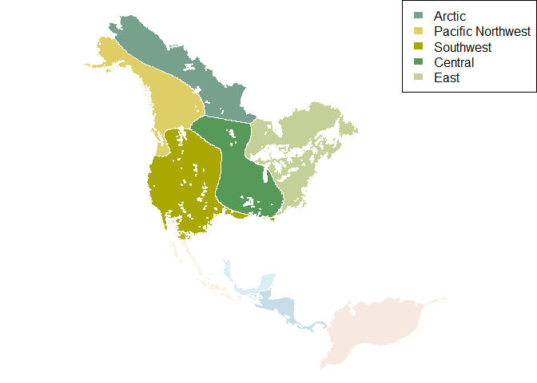

Yellow Warbler breeding regions. The breeding regions are defined by genoscape-defined populations and the nonbreeding regions (washed out) were identified by ecoregions across the ranges

### Sample data

For information about sampling and assignment methods see Bay et al. (2021) for genetics and Witynski and Bonter (2018) for geolocators.

### Load the genetic sample data

```r
#read in the data
genetic_samples <- read.delim("YEWA_nonbreeding_genetic_samples.txt",
                              stringsAsFactors = TRUE)

str(genetic_samples, 1)
```

```
## 'data.frame':    203 obs. of  12 variables:
##  $ mixture_collection: Factor w/ 1 level "mixture": 1 1 1 1 1 1 1 1 1 1 ...
##  $ indiv             : Factor w/ 203 levels "02N0291","04N8955",..: 1 2 3 4 5 6 7 8 9 10 ...
##  $ Alaska            : num  6.16e-03 1.91e-17 1.86e-18 1.38e-20 5.45e-11 ...
##  $ Central           : num  1.34e-29 1.00 1.00 1.00 9.98e-01 ...
##  $ Southwest         : num  1.29e-03 1.50e-09 3.67e-09 4.26e-11 1.62e-03 ...
##  $ East              : num  9.57e-66 2.24e-11 7.78e-11 1.69e-10 1.49e-17 ...
##  $ WesternBoreal     : num  9.93e-01 1.41e-16 5.49e-18 2.65e-20 1.07e-08 ...
##  $ State             : Factor w/ 14 levels "Ahuachapan","Baja California Sur",..: 4 5 5 5 5 5 5 5 5 5 ...
##  $ Town              : Factor w/ 20 levels "Celestun","Chamela",..: 5 6 6 6 6 6 6 6 6 6 ...
##  $ Stage             : Factor w/ 1 level "Wintering": 1 1 1 1 1 1 1 1 1 1 ...
##  $ longitude         : num  -86 -85.6 -85.6 -85.6 -85.6 ...
##  $ latitude          : num  11.8 10.6 10.6 10.6 10.6 10.6 10.6 10.6 10.6 10.6 ...
```

The genetic data have the probability that each individual is assigned to a specific genetic population. These data are used during the resampling process to estimate transition probabilities and the strength of MC. Below, we format the data so we can easily use it in our analysis.

```r
# Note that we re-order the probabilities to match the order of originNames #
YEWA_genetics <- as.matrix(genetic_samples[,c("Alaska","WesternBoreal",
                                              "Southwest","Central",
                                              "East")])

# give names to the object
dimnames(YEWA_genetics) <- list(as.character(genetic_samples$indiv),
                                originNames)

# Double-check that all rows sum to 1
summary(rowSums(YEWA_genetics))
```

```
##    Min. 1st Qu.  Median    Mean 3rd Qu.    Max.
##       1       1       1       1       1       1
```

Convert the data into a spatial object

```r
# Convert the data into spatial object
targetPoints_genetic <- st_as_sf(genetic_samples[,c("longitude","latitude")],
                                  coords = c("longitude","latitude"),
                                  crs = 4326) # WGS84

# Assign the data type to the spatial layer

targetPoints_genetic$Type <- "Genetics Capture"
```

### Load the light-level geolocator data

We obtained location estimates from seven individuals tracked using light-level geolocators deployed and recovered in Maine (n = 4) and Wisconsin (n = 3; Witynski & Bonter, 2018). We used the daily location estimates while individuals remained on the breeding grounds to derive location bias and uncertainty estimates. The geolocator data were processed and reported by Witynski and Bonter (2018).

```r
# Capture locations #
# See dates and summary data from Table 1. page 44.
# Maine #129
# Maine #132
# Maine #136
# Maine #137
# Wisconsin #139
# Wisconsin #144
# Wisconsin #146

caplocs <- cbind(c(rep(-70.6142,4),rep(-87.8123,3)),
                 c(rep(42.9891,4),rep(42.5000,3)))

# Departures #
departs <- as.POSIXct(c("2015-09-04",
                        "2015-08-22",
                        "2015-09-04",
                        "2015-08-28",
                        "2015-08-24",
                        "2015-08-24",
                        "2015-08-30"))
```

```r
# read in the daily location data #
EstLocs <- read.csv("Yellow Warbler_Witynski.csv")

# make it spatial
YEWA_gl_locs <- sf::st_as_sf(EstLocs,
                             coords = c("location.long",
                                        "location.lat"),
                             crs = 4326)
```

```r
# Summarized nonbreeding locations reported in Witynski and Bonter

YEWA_GL_nb <- sf::st_as_sf(data.frame(bird = factor(c(129,132,136,137,139,144,146)),
                                      long = c(-75.09,-74.81,-74.30,-74.21,-68.72,-67.08,-65.39),
                                      lat = c(10.03,8.52,10.51,3.14,0.96,5.73,6.67)),
                               coords = c("long","lat"),
                               crs = 4326)

# assign type to GL spatial object
YEWA_GL_nb$Type <- "GL Estimated Target"

# Convert the capture locations to a spatial object
YEWA_GL_breed <- st_as_sf(data.frame(bird = c(129,132,136,137,139,144,146),
                                  longitude = caplocs[,1],
                                  latitude = caplocs[,2]),
                       coords = c("longitude","latitude"),
                       crs = 4326)

# assign type to GL spatial object
YEWA_GL_breed$Type <- "GL Capture"
```

Calculate location bias and covariance which are used to estimate transition probabilities (`estTransition`).

```r
# project from WGS84 into meters #
YEWAmeters <- sf::st_transform(YEWA_gl_locs,'ESRI:102010')
CapMeters <- sf::st_transform(YEWA_GL_breed, 'ESRI:102010')

# split birds into their own data #
YEWAests <- split(YEWAmeters,
                  f = YEWAmeters$'individual.local.identifier')

# Empirical estimates of bias and vcov, but on mean locations by bird
ests2 <- mapply(x = YEWAests,
                lats = st_coordinates(CapMeters)[,2],
                lng = st_coordinates(CapMeters)[,1],
                z = departs,
                FUN = function(x,lats,lng,z){
              # keep only data from deployment until departure from breeding #
                  newdata <- x[x$timestamp<z,]

              # calculate the difference in meters from estimated location
              # to actual capture location
                  long <- mean(st_coordinates(newdata)[,1]) - lng
                  lat <- mean(st_coordinates(newdata)[,2]) - lats

                  return(c(difflong = long,
                                    difflat = lat))},

               SIMPLIFY = TRUE)

(geoBiasYEWA <- apply(ests2, 1, mean)) #Bias
```

```
##  difflong   difflat
## -6512.898 50964.969
```

```r
(geoVCovYEWA <- cov(t(ests2))) #Variance-covariance matrix
```

```
##            difflong    difflat
## difflong  259401516 -894387951
## difflat  -894387951 4708578511
```

### Set up input to run estTransition

The following code creates objects that are needed and/or helpful when using the `estStrength` or `estTransition` functions.

```r
## Set up input for running in estTransition

# Number of geolocator birds
nGL <- nrow(YEWA_GL_breed)

# We have 0 birds with telemetry data
nTelemetry <- 0

# How many birds have raster data (isotopes; for this example, none)
nRaster <- 0

# How many birds have probability data (genetics)
nProb <- nrow(YEWA_genetics)

# Total number of animals
nAnimals <- nGL + nTelemetry + nRaster + nProb

# Set up a vector of TRUE/FALSE indicating if the individual
# has geolocator data
isGLYEWA <- rep(c(TRUE, FALSE), c(nGL, nTelemetry + nRaster + nProb))

# Vector indicating whether an individual has telemetry data
isTelemetryYEWA <- rep(FALSE, nAnimals)

# Vector indicating whether an individual has raster assignment data
isRasterYEWA <- rep(FALSE, nAnimals)

# Vector indicating whether an individual has probability data
isProbYEWA <- rep(c(FALSE, TRUE), c(nGL + nTelemetry + nRaster, nProb))
```

Now that we have objects that tell the function which type of data are associated with each individual we can set up the spatial data.

```r
# combine all the target locations into a single object
# NOTE - we reorder the columns to match between the data sets
targetPointsYEWA <- rbind(YEWA_GL_nb[,c("Type","geometry")],
                          targetPoints_genetic[,c("Type","geometry")])

# Transform (re-project the data) into Equidistant conic projection
targetPointsYEWA <- st_transform(targetPointsYEWA, "ESRI:102010")

# A vector indicating where the birds were captured
capturedYEWA <- rep(c("origin", "target"), c(nGL, nTelemetry + nRaster + nProb))
```

Here we do some spatial analyses to determine target sites from the data we’ve gathered so far. These data are needed for the analysis.

```r
# Where birds were captured in the origin sites (i.e., geolocators)
originPointsYEWA <- CapMeters

# Transform (re-project) data into Equidistant conic projection
targetSitesYEWA <- st_transform(YEWA_target_sites, "ESRI:102010")

# Create a vector of the target assignments of the input data
targetAssignment <- suppressMessages(unclass(sf::st_intersects(x = targetPointsYEWA,
                                                               y = targetSitesYEWA,
                                                               sparse = TRUE)))

# Set any target assignment that results in 0 to NA
targetAssignment[lengths(targetAssignment)==0] <- NA

# convert from a list to an array #
targetAssignment <- array(unlist(targetAssignment))

# If the assignment is NA - assign to the nearest targetSite
targetAssignment[is.na(targetAssignment)] <- sf::st_nearest_feature(x = targetPointsYEWA[is.na(targetAssignment),],
                                                                    y = targetSitesYEWA)
```

### Abundance estimates

Accounting for relative abundance is an important component when estimating migratory connectivity strength or estimating transition probabilities between two or more phases of the annual cycle.

Below, we use eBird.org products to estimate abundance. Note - users may need to create an account and get permission to access eBird data. See information to [Download eBird data products](https://science.ebird.org/en/use-ebird-data/download-ebird-data-products).

```r
# Read in data from eBird
library(ebirdst)
library(tidyverse)

sp_path <- ebirdst_download_status(species = "yelwar", path = "./data/")

ebird <- load_raster("yelwar", path = "./data/",
                     product = "abundance",
                     period = "seasonal",
                     metric = "mean",
                     resolution = "9km")  #medium resolution to match old code

## NOTE: parse_raster_dates is now defunct.
# workaround -- divide abundance raster by season and estimate relative abundance

b <- ebird[['breeding']]
w <- ebird[['nonbreeding']]

targetSitesProj <- sf::st_transform(targetSitesYEWA, terra::crs(w))
originSitesProj <- sf::st_transform(YEWA_origin_sites, terra::crs(b))

relAbundYEWAWint <- terra::extract(w, targetSitesProj, fun = 'sum', na.rm = T)
relAbundYEWAWint$rel <- relAbundYEWAWint$nonbreeding /
  sum(relAbundYEWAWint$nonbreeding)
relAbundYEWAWint <- relAbundYEWAWint$rel
names(relAbundYEWAWint) <- targetNames

relAbundYEWABreed <- terra::extract(b, originSitesProj, fun = 'sum', na.rm = T)
relAbundYEWABreed$rel <- relAbundYEWABreed$breeding /
  sum(relAbundYEWABreed$breeding)
relAbundYEWABreed <- relAbundYEWABreed$rel
names(relAbundYEWABreed) <- originNames
```

```r
relAbundYEWAWint
```

```
## Pacific and Central Mexico    Atlantic Lowland Mexico
##                 0.09903443                 0.18604479
##            Central America              South America
##                 0.43239219                 0.28252859
```

```r
relAbundYEWABreed
```

```
##            Arctic Pacific Northwest         Southwest           Central
##         0.1644263         0.1167522         0.2902441         0.2394759
##              East
##         0.1891015
```

There are a few other things we would need for eventually running `estStrength`: the distances between breeding regions, and the distances between nonbreeding regions.

```r
# calculate distance between originSites
originCentersYEWA <- st_centroid(YEWA_origin_sites)
originCentersYEWA <- st_transform(originCentersYEWA, 4326)
originDistYEWA <- distFromPos(st_coordinates(originCentersYEWA$geometry))

# calculate distance between targetSites
targetCentersYEWA <- st_centroid(YEWA_target_sites)
targetCentersYEWA <- st_transform(targetCentersYEWA, 4326)
targetDistYEWA <- distFromPos(st_coordinates(targetCentersYEWA$geometry))
```

We now have all the data in order to run `estTransition` and then `estStrength`.

Note - there was no overlap of data sources for individuals, i.e., we only had one type of data for each bird - so we set the overlap setting to “none”. If there are multiple types for an individual animal or only one type of data overall, it’s best to leave `dataOverlapSetting` at its default (“dummy”).

```r
## Run analysis for psi
system.time((psiYEWA <- estTransition(originSites = YEWA_origin_sites,
                                     targetSites = YEWA_target_sites,
                                     originPoints = originPointsYEWA,
                                     targetPoints = targetPointsYEWA,
                                     originAssignment = YEWA_genetics,
                                     originNames = originNames,
                                     targetNames = targetNames,
                                     nSamples = 10, # Set low for demonstration speed
                                     isGL = isGLYEWA,
                                     isTelemetry = isTelemetryYEWA,
                                     isRaster = isRasterYEWA,
                                     isProb = isProbYEWA,
                                     captured = capturedYEWA,
                                     geoBias = geoBiasYEWA,
                                     geoVCov = geoVCovYEWA,
                                     verbose = 2,
                                     maxTries = 400,
                                     resampleProjection = st_crs(YEWA_origin_sites),
                                     nSim = 40,
                                     dataOverlapSetting = "none",
                                     targetRelAbund = relAbundYEWAWint)))
```

```
## Configuring data overlap settings
```

```
## Creating targetAssignment
## Not all target capture locations are within targetSites. Assigning to closest site
```

```
## Starting bootstrap
## Bootstrap Run 1 of 10 at Mon Mar 31 15:13:44 2025
## Bootstrap Run 2 of 10 at Mon Mar 31 15:13:44 2025
## Bootstrap Run 3 of 10 at Mon Mar 31 15:13:45 2025
## Bootstrap Run 4 of 10 at Mon Mar 31 15:13:45 2025
## Bootstrap Run 5 of 10 at Mon Mar 31 15:13:45 2025
## Bootstrap Run 6 of 10 at Mon Mar 31 15:13:45 2025
## Bootstrap Run 7 of 10 at Mon Mar 31 15:13:45 2025
## Bootstrap Run 8 of 10 at Mon Mar 31 15:13:46 2025
## Bootstrap Run 9 of 10 at Mon Mar 31 15:13:46 2025
## Bootstrap Run 10 of 10 at Mon Mar 31 15:13:46 2025
```

```
##    user  system elapsed
##    1.57    0.13    2.64
```

```r
# Take a look at the results #
psiYEWA
```

```
## Migratory Connectivity Estimates
##
## Transition probability (psi) estimates (mean):
##                   Pacific and Central Mexico Atlantic Lowland Mexico
## Arctic                               0.00000                 0.70529
## Pacific Northwest                    0.03831                 0.21765
## Southwest                            0.41451                 0.07355
## Central                              0.00000                 0.10223
## East                                 0.00000                 0.00000
##                   Central America South America
## Arctic                     0.2947        0.0000
## Pacific Northwest          0.7440        0.0000
## Southwest                  0.5119        0.0000
## Central                    0.6426        0.2551
## East                       0.0000        1.0000
## +/- SE:
##                   Pacific and Central Mexico Atlantic Lowland Mexico
## Arctic                               0.00000                 0.10752
## Pacific Northwest                    0.03137                 0.10038
## Southwest                            0.08314                 0.05332
## Central                              0.00000                 0.03427
## East                                 0.00000                 0.00000
##                   Central America South America
## Arctic                    0.10752        0.0000
## Pacific Northwest         0.10511        0.0000
## Southwest                 0.08505        0.0000
## Central                   0.05170        0.0473
## East                      0.00000        0.0000
## 95% confidence interval (simple quantile):
##                   Pacific and Central Mexico Atlantic Lowland Mexico
## Arctic            0.00000 - 0.00000          0.51607 - 0.82623
## Pacific Northwest 0.00000 - 0.08125          0.08462 - 0.37562
## Southwest         0.29585 - 0.55664          0.02326 - 0.18098
## Central           0.00000 - 0.00000          0.04856 - 0.16346
## East              0.00000 - 0.00000          0.00000 - 0.00000
##                   Central America   South America
## Arctic            0.17377 - 0.48393 0.00000 - 0.00000
## Pacific Northwest 0.56335 - 0.89872 0.00000 - 0.00000
## Southwest         0.35957 - 0.60463 0.00000 - 0.00000
## Central           0.55674 - 0.71436 0.18649 - 0.32708
## East              0.00000 - 0.00000 1.00000 - 1.00000
##
## This is a subset of what's available inside this estMigConnectivity output.
## For more info, try ?estTransition or str(obj_name, max.level = 2).
```

Plot the results using the built-in plotting function

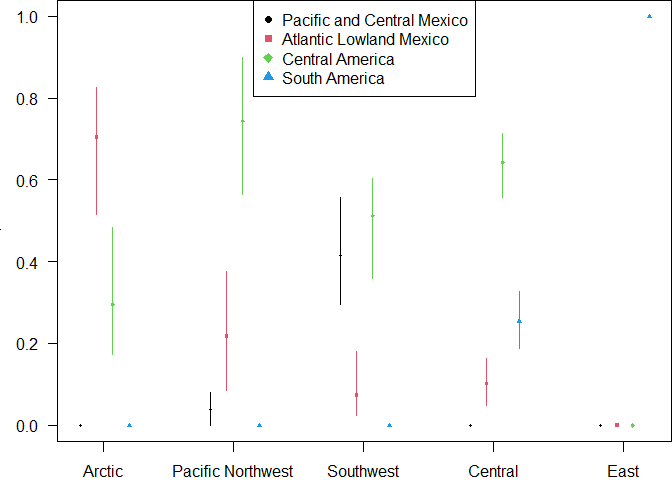

Estimated transition probabilities of the Yellow Warbler between breeding and nonbreeding periods

```r
par(mar = c(2,3,0,0))
plot(psiYEWA, legend = "top", cex = 0.4)
```

## Calculating location bias and covariance structure to resample light-level geolocator data

#### SGAT

The code below is a repeatable example for how to calculate location bias and location error using coordinates derived from light-level geolocators (see Cohen et al. (2018)) analyzed using the SGAT package (Wotherspoon 2017, Lisovski et al. 2020).

```r
# Load in projections
data("projections")

# Define deployment locations (winter) #
captureLocations<-matrix(c(-77.93,18.04,   # Jamaica
                           -80.94,25.13,   # Florida
                           -66.86,17.97),  # Puerto Rico
                            nrow=3, ncol=2, byrow = TRUE)

colnames(captureLocations) <- c("Longitude","Latitude")

# Convert capture locations into SpatialPoints #

CapLocs <- sf::st_as_sf(data.frame(captureLocations),
                      coords = c("Longitude","Latitude"),
                      crs = 4326)

# Project Capture locations #

CapLocsM<-sf::st_transform(CapLocs, 'ESRI:54027')

# Retrieve raw non-breeding locations from github
# First grab the identity of the bird so we can loop through the files
# For this example we are only interested in the error
# around non-breeding locations
# here we grab only the birds captured during the non-breeding season
# Using paste0 for vignette formatting purposes

winterBirds <- dget(paste0("https://raw.githubusercontent.com/",
                    "SMBC-NZP/MigConnectivity/master/",
                    "data-raw/GL_NonBreedingFiles/winterBirds.txt"))

# create empty list to store the location data #
Non_breeding_files <- vector('list',length(winterBirds))

# Get raw location data from Github #
for(i in 1:length(winterBirds)){
Non_breeding_files[[i]] <- dget(paste0("https://raw.githubusercontent.com/",
                                        "SMBC-NZP/MigConnectivity/master/data-raw/",
                                        "GL_NonBreedingFiles/NonBreeding_",
                                        winterBirds[i],".txt"))
}

# Remove locations around spring Equinox and potential migration points
# same NB time frame as Hallworth et al. 2015

# two steps because subset on shapefile doesn't like it in a single step

Non_breeding_files <- lapply(Non_breeding_files,
                      FUN = function(x){
                      month <- as.numeric(format(x$Date,format = "%m"))
                               x[which(month != 3 & month != 4),]})


Jam <- c(1:9)   # locations w/in list of winterBirds captured in Jamaica
Fla <- c(10:12) # locations w/in list of winterBirds in Florida
PR <- c(13:16)  # locations w/in list of winterBirds in Puerto Rico

# Turn the locations into shapefiles #

NB_GL <- lapply(Non_breeding_files,
                FUN = function(x){
                  sf::st_as_sf(data.frame(x),
                               coords = c("Longitude",
                                          "Latitude"),
                               crs = 4326)})

# Project into UTM projection #

NB_GLmeters <- lapply(NB_GL,
                      FUN = function(x){sf::st_transform(x,'ESRI:54027')})

# Process to determine geolocator bias and variance-covariance in meters #

# generate empty vector to store data #
LongError<-rep(NA,length(winterBirds))
LatError<-rep(NA,length(winterBirds))

# Calculate the error in longitude derived
# from geolocators from the true capture location

LongError[Jam] <- unlist(lapply(NB_GLmeters[Jam],
                         FUN = function(x){mean(sf::st_coordinates(x)[,1]-
                                                  sf::st_coordinates(CapLocsM)[1,1])}))

LongError[Fla] <- unlist(lapply(NB_GLmeters[Fla],
                         FUN = function(x){mean(sf::st_coordinates(x)[,1]-
                                                  sf::st_coordinates(CapLocsM)[2,1])}))

LongError[PR] <- unlist(lapply(NB_GLmeters[PR],
                        FUN = function(x){mean(sf::st_coordinates(x)[,1]-
                                                 sf::st_coordinates(CapLocsM)[3,1])}))

# Calculate the error in latitude derived from
# geolocators from the true capture location

LatError[Jam] <- unlist(lapply(NB_GLmeters[Jam],
                        FUN = function(x){mean(sf::st_coordinates(x)[,2]-
                                                  sf::st_coordinates(CapLocsM)[1,2])}))

LatError[Fla] <- unlist(lapply(NB_GLmeters[Fla],
                        FUN = function(x){mean(sf::st_coordinates(x)[,2]-
                                                 sf::st_coordinates(CapLocsM)[2,2])}))

LatError[PR] <- unlist(lapply(NB_GLmeters[PR],
                        FUN = function(x){mean(sf::st_coordinates(x)[,2]-
                                                  sf::st_coordinates(CapLocsM)[3,2])}))

# Get co-variance matrix for error of
# known non-breeding deployment sites

# lm does multivariate normal models if you give it a matrix dependent variable!

geo.error.model <- lm(cbind(LongError,LatError) ~ 1)

geo.bias <- coef(geo.error.model)
geo.vcov <- vcov(geo.error.model)
```

#### FLightR

The code below is a repeatable example for how to calculate location bias and location error using location estimates derived from light-level geolocators analyzed in FLightR (Rakhimberdiev et al. 2017, Lisovski et al. 2020). The geolocator data were processed and reported by Witynski and Bonter (2018).

```r
# Capture locations #
# See dates and summary data from Table 1. page 44.
# Maine #129
# Maine #132
# Maine #136
# Maine #137
# Wisconsin #139
# Wisconsin #144
# Wisconsin #146

caplocs <- cbind(c(rep(-70.6142,4),rep(-87.8123,3)),
                 c(rep(42.9891,4),rep(42.5000,3)))

# Departures #
departs <- as.POSIXct(c("2015-09-04","2015-08-22","2015-09-04","2015-08-28","2015-08-24","2015-08-24","2015-08-30"))

# read in the daily location data #
EstLocs <- read.csv("Yellow Warbler_Witynski (1).csv")

YEWAsf <- st_as_sf(EstLocs, coords = c("location.long","location.lat"), crs = 4326)

caplocs_sf <- st_as_sf(data.frame(bird = c(129,132,136,137,139,144,146),
                                  longitude = caplocs[,1],
                                  latitude = caplocs[,2]),
                       coords = c("longitude","latitude"),
                       crs = 4326)

# project into meters #
YEWAmeters <- sf::st_transform(YEWAsf,'ESRI:102010')
CapMeters <- sf::st_transform(caplocs_sf, 'ESRI:102010')

# split birds into their own data #

YEWAests <- split(YEWAmeters, f=YEWAmeters$'individual.local.identifier')

# Empirical estimates of bias and vcov, but on mean locations by bird
ests2 <- mapply(x = YEWAests,
                lats = st_coordinates(CapMeters)[,2],
                lng = st_coordinates(CapMeters)[,1],
                z = departs,
                FUN = function(x,lats,lng,z){
                  # keep only data from deployment until departure from breeding #
                  newdata <- x[x$timestamp<z,]

                  # calculate the difference in meters from estimated location
                  # to actual capture location
                  long <- mean(st_coordinates(newdata)[,1]) - lng
                  lat <- mean(st_coordinates(newdata)[,2]) - lats

                  return(c(difflong = long,
                                    difflat = lat))},

               SIMPLIFY = TRUE)

(geoBiasYEWA <- apply(ests2, 1, mean)) #Bias
#  difflong   difflat
# -6512.898 50964.969

apply(ests2, 1, var) #Variances
apply(ests2, 1, sd)

(geoVCovYEWA <- cov(t(ests2))) #Variance-covariance matrix

#            difflong    difflat
# difflong  259401516 -894387951
# difflat  -894387951 4708578511
```

### Literature Cited

Bay, R. A., D. S. Karp, J. F. Saracco, W. R. L. Anderegg, L. O. Frishkoff, D. Wiedenfeld, T. B. Smith, and K. Ruegg. 2021. [Genetic Variation Reveals Individual-Level Climate Tracking across the Annual Cycle of a Migratory Bird](https://doi.org/10.1111/ele.13706). Ecology Letters 24:819–828.

Cohen, E. B., J. A. Hostetler, M. T. Hallworth, C. S. Rushing, T. S. Sillett, and P. P. Marra. 2018. [Quantifying the strength of migratory connectivity](https://doi.org/10.1111/2041-210X.12916). Methods in Ecology and Evolution 9:513–524.

Hostetler, J. A., E. B. Cohen, C. M. Bossu, A. L. Scarpignato, K. Ruegg, A. Contina, C. S. Rushing, and M. T. Hallworth. 2025. [Challenges and opportunities for data integration to improve estimation of migratory connectivity](https://doi.org/10.1111/2041-210X.14467). Methods in Ecology and Evolution 16:362–376.

Lisovski, S., S. Bauer, M. Briedis, S. C. Davidson, K. L. Dhanjal-Adams, M. T. Hallworth, J. Karagicheva, C. M. Meier, B. Merkel, J. Ouwehand, L. Pedersen, E. Rakhimberdiev, A. Roberto-Charron, N. E. Seavy, M. D. Sumner, C. M. Taylor, S. J. Wotherspoon, and E. S. Bridge. 2020. [Light-Level Geolocator Analyses: A User’s Guide](https://doi.org/10.1111/1365-2656.13036). Journal of Animal Ecology 89:221–236.

Rakhimberdiev, E., A. Saveliev, T. Piersma, and J. Karagicheva. 2017. [FLightR: An r Package for Reconstructing Animal Paths from Solar Geolocation Loggers](https://doi.org/10.1111/2041-210X.12765). Methods in Ecology and Evolution 8:1482–1487.

Witynski, M. L., and D. N. Bonter. 2018. [Crosswise Migration by Yellow Warblers, Nearctic-Neotropical Passerine Migrants](https://doi.org/10.1111/jofo.12237). Journal of Field Ornithology 89:37–46.

Wotherspoon, S. 2017. SGAT: Solar/Satellite Geolocation for Animal Tracking.